# 第3回 データの可視化（1）：ggplot2によるグラフ作成の基礎

行動計量学（行動科学分析法入門）

小野原 彩香

令和8年度

**【お知らせ】来週 10月23日（金）は休講です。** 担当教員の研究出張のため休講となり，**第4回以降を1週ずつ繰り下げます。** 次回の第4回「データの可視化(2)」は **10月30日（金）** です。

空く2週間のあいだに，下の**宿題（`.R` ファイルの保存）**を済ませておいてください。

## 本日の目標

1. `ggplot2` の基本的な考え方（レイヤー構造）を理解する
2. 散布図・ヒストグラム・棒グラフ・箱ひげ図を作成できる
3. `aes()` による**変数の対応づけ**と，**見た目の固定指定**を区別できる
4. **作った図が何を表しているかを説明できる**

## 0. 前回の宿題の確認：保存先と，終了するときの「保存」

本題に入る前に，前回の宿題（演習1〜4を1つの `.R` ファイルに保存する）を確認します。

**まず，保存した `.R` ファイルを開いてください。** 開けたら，上から順に実行してみます。 ここでつまずく人が毎年います。原因はたいてい次の2つなので，先に片づけておきます。 どちらも「ファイルがどこに行ったか分からない」「前に書いたコードが動かない」の正体です。

> **解答例**：第2回 演習の模範解答（`.R` ファイル） 自分の答えと見比べてください。追加問題（体重65kgのBMI）と， `install.packages()` と `library()` の違いも入っています。

### 0-1. ファイルの保存先と，プロジェクト

**ファイルが見つからない人は，保存先が「デスクトップ」や「ダウンロード」になっています。** `File` → `Recent Files` から開き直せることが多いので，まず試してください。 開けたら，この授業用のフォルダに置き直します。その整え方が**プロジェクト**です。

**プロジェクトとは，1つのフォルダを「分析のひとまとまり」としてRStudioに覚えさせる仕組み**です。 作ると，そのフォルダの中に `○○.Rproj` というファイルが1つできます。これがプロジェクトの本体です。

プロジェクトを使うと，次の4つが自動で片づきます。

| 困ること | プロジェクトを使うと |
| --- | --- |
| ファイルを読み込むとき，長いパスを書かないといけない | **そのフォルダが自動で作業場所になる**ので，`read.csv("data/kekka.csv")` のように短く書ける |
| `setwd("C:/Users/...")` を毎回書き換えている | **書かなくてよくなる**（`setwd()` は使わないのが現代的な流儀です） |
| 別の課題のデータや変数が混ざる | 分析ごとにフォルダが分かれ，**開いていたタブもそのまま復元される** |
| USBや別のPCに移したらパスが全部壊れた | **フォルダごと移動してもそのまま動く** |

**作り方**

1. `File` → `New Project...`
2. `New Directory` → `New Project`
3. `Directory name` にフォルダ名，`Create project as subdirectory of` に置き場所を指定
4. `Create Project`

この授業では，たとえば `kodo-keiryo` という名前のプロジェクトを1つ作り， その中に回ごとの `.R` ファイルを置いていくとよいでしょう。 前回保存したファイルも，このフォルダに移しておいてください。

> **フォルダ名と置き場所の注意**
> - 名前に**日本語・スペースを使わない**（`第3回 課題` ではなく `week03` のように）
> - **OneDrive / iCloud の同期フォルダは避ける**。同期とRの書き込みがぶつかって保存に失敗することがあります

> すでにフォルダがある人は，手順2で `Existing Directory` を選べば，そのフォルダをプロジェクトにできます。

**開き方**：`.Rproj` ファイルをダブルクリックします。 RStudioの**右上**に今開いているプロジェクト名が出ているので，そこから切り替えることもできます。 いまどこで作業しているか確かめたいときは `getwd()` を実行します。

### 0-2. 終了するときに聞かれる「保存」は2種類ある

RStudioを閉じようとすると保存を聞かれますが，**聞かれているものが2種類あり，答えが逆になります。**

**① スクリプト（`.R` ファイル）の保存 → 必ず保存する**

タブの名前が**赤くなっていたり `*` が付いていたら未保存**です。これはあなたが書いたコードそのもの，つまり成果物です。`Ctrl + S`（Macは `Cmd + S`）で保存してください。

**② 「Save workspace image to ~/.RData?」 → 保存しなくてよい（`Don't Save`）**

RStudioを閉じるときに出てくる，あの英語の確認画面です。これは **「いま変数に入っているデータを，次回も残しておきますか」**という質問です。 `Save` / `Don't Save` / `Cancel` の3択なら，**`Don't Save` を選んでください。**

|  | 中身 | 答え |
| --- | --- | --- |
| `.R` ファイル | 書いたコード | **保存する** |
| `.RData`（ワークスペース） | 実行してできた変数・データ | **保存しなくてよい** |
| `.Rhistory` | コンソールに打った履歴 | 保存しなくてよい |

**なぜ保存しなくてよいのか。** コードが残っていれば，変数は実行し直せば作り直せます。 むしろ保存すると困ることが起きます。

> 前回の古い変数が残ったまま次回が始まるので， **コードを直したのに結果が変わらない**，逆に **コードを消したのに動いてしまう**（消したはずの変数がまだメモリにいる）ということが起きます。 そうなると，そのコードを他の人に渡しても動きません。

> **「まっさらな状態から上から順に実行すれば，同じ結果になる」**という状態を保つこと。 これが分析の**再現性**で，この授業でずっと大事にしてほしい考え方です。

**毎回聞かれないようにする設定（おすすめ）**

1. `Tools` → `Global Options...` → `General`
2. **`Save workspace to .RData on exit:`** を **`Never`** にする
3. **`Restore .RData into workspace at startup`** の**チェックを外す**

これで聞かれなくなり，起動のたびにまっさらな状態から始まります。

> **例外**：計算に何十分もかかった結果だけは，残したいことがあります。 そのときはワークスペース全体ではなく，必要なものだけを明示的に保存します。

> ```r
> saveRDS(kekka, "kekka.rds")   # 保存
> kekka <- readRDS("kekka.rds") # 読み込み
> ```

## 1. ggplot2とは

`ggplot2` は，Rで最も広く使われているグラフ作成パッケージです。

### ggplot2の特徴

- **文法に基づいたグラフ作成**（Grammar of Graphics）
- レイヤーを重ねてグラフを組み立てる
- 美しいデフォルトデザイン
- 高度なカスタマイズが可能

```r
# tidyverse を読み込む（ggplot2が含まれる）
library(tidyverse)
```

## 2. ggplot2の基本構造

### レイヤー構造

ggplot2では，グラフを**レイヤー（層）を重ねる**ように作ります。

```r
ggplot(data = データ, aes(x = x軸の変数, y = y軸の変数)) +
  geom_xxx()   # グラフの種類を指定
```

| 要素 | 説明 |
| --- | --- |
| `ggplot()` | キャンバスを準備する |
| `aes()` | 変数とグラフ要素のマッピングを指定 |
| `geom_xxx()` | グラフの種類（散布図・棒グラフなど） |

> **上の「データ」「x軸の変数」「`geom_xxx()`」は，構造を示すための仮の書き方です。** そのまま打っても動きません。実際の名前に置き換えて使います。

### 複数行にまたがるコードの実行

今日から，`+` で次の行へ続くコードが中心になります。

```r
ggplot(data = iris, aes(x = Sepal.Length)) +
  geom_histogram()
```

これは**2行で1つのグラフ**です。`geom_histogram()` の行だけを実行しても図は出ません。

> **グラフのコード全体をドラッグで選択してから，`Ctrl + Enter`（Macは `Cmd + Enter`）**で実行してください。 選択した範囲がそのままコンソールに送られます。

## 3. 練習用データの準備

今日は R に最初から入っているデータセット `iris` を使います。

```r
# データの確認
head(iris)      # 最初の6行を表示
```

|  | Sepal.Length | Sepal.Width | Petal.Length | Petal.Width | Species |
| --- | --- | --- | --- | --- | --- |
| 1 | 5.1 | 3.5 | 1.4 | 0.2 | setosa |
| 2 | 4.9 | 3.0 | 1.4 | 0.2 | setosa |
| 3 | 4.7 | 3.2 | 1.3 | 0.2 | setosa |
| 4 | 4.6 | 3.1 | 1.5 | 0.2 | setosa |
| 5 | 5.0 | 3.6 | 1.4 | 0.2 | setosa |
| 6 | 5.4 | 3.9 | 1.7 | 0.4 | setosa |

```r
# データの概要
str(iris)
```

```
## 'data.frame':    150 obs. of  5 variables:
##  $ Sepal.Length: num  5.1 4.9 4.7 4.6 5 5.4 4.6 5 4.4 4.9 ...
##  $ Sepal.Width : num  3.5 3 3.2 3.1 3.6 3.9 3.4 3.4 2.9 3.1 ...
##  $ Petal.Length: num  1.4 1.4 1.3 1.5 1.4 1.7 1.4 1.5 1.4 1.5 ...
##  $ Petal.Width : num  0.2 0.2 0.2 0.2 0.2 0.4 0.3 0.2 0.2 0.1 ...
##  $ Species     : Factor w/ 3 levels "setosa","versicolor",..: 1 1 1 1 1 1 1 1 1 1 ...
```

```r
# 基本統計量
summary(iris)
```

```
##   Sepal.Length    Sepal.Width     Petal.Length    Petal.Width
##  Min.   :4.300   Min.   :2.000   Min.   :1.000   Min.   :0.100
##  1st Qu.:5.100   1st Qu.:2.800   1st Qu.:1.600   1st Qu.:0.300
##  Median :5.800   Median :3.000   Median :4.350   Median :1.300
##  Mean   :5.843   Mean   :3.057   Mean   :3.758   Mean   :1.199
##  3rd Qu.:6.400   3rd Qu.:3.300   3rd Qu.:5.100   3rd Qu.:1.800
##  Max.   :7.900   Max.   :4.400   Max.   :6.900   Max.   :2.500
##        Species
##  setosa    :50
##  versicolor:50
##  virginica :50
##
##
##
```

### このデータは何か

前回はベクトル（数値が一列に並んだもの）を扱いました。今日からは**表の形をしたデータ**を使います。

> **`iris` は 150行・5列のデータフレームです。**
> - **1行が，1本の花の観測**です。全部で150本
> - **1列が，測定項目または種**です

| 列名 | 内容 | 単位 |
| --- | --- | --- |
| `Sepal.Length` | がく片の長さ | cm |
| `Sepal.Width` | がく片の幅 | cm |
| `Petal.Length` | 花びらの長さ | cm |
| `Petal.Width` | 花びらの幅 | cm |
| `Species` | 種（setosa / versicolor / virginica） | — |

3つの種が**それぞれ50本ずつ**入っています。

この「1行＝1つの観測」という構造が分かると，**散布図の点1つが何を表すか**が見えてきます。点1つが，1本の花です。

> `str()` の出力は情報が多いですが，いま読み取るのは2つだけです。 **「何行・何列か」**と，**「数値の列と，種を表すカテゴリの列があること」**です。 記号をすべて覚える必要はありません。

## 4. 散布図（Scatter Plot）

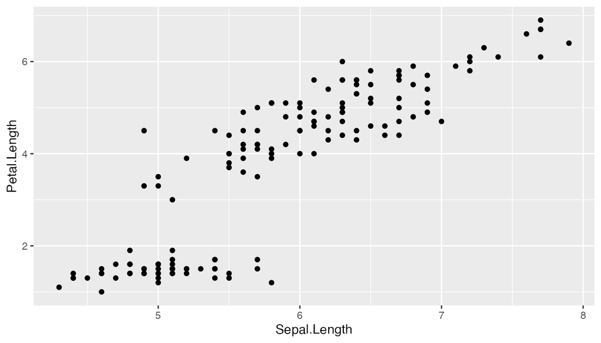

```r
ggplot(data = iris, aes(x = Sepal.Length, y = Petal.Length)) +
  geom_point()
```

### 色で種類を区別する

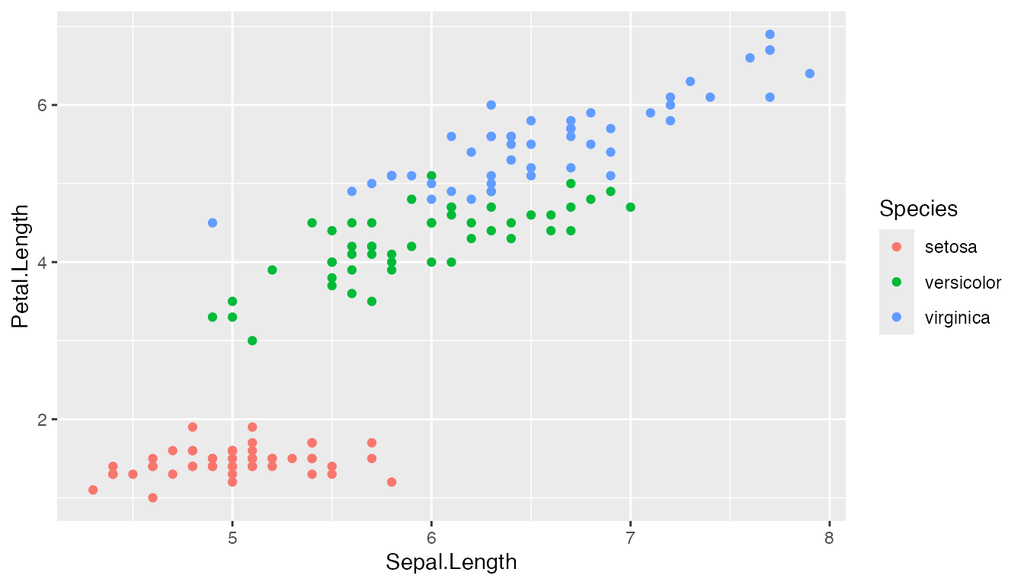

```r
ggplot(data = iris, aes(x = Sepal.Length, y = Petal.Length, color = Species)) +
  geom_point()
```

### `aes()` の中と外では意味が違う

**ここが今日いちばん間違えやすいところです。**

| 書く場所 | 意味 | 例 |
| --- | --- | --- |
| **`aes()` の中** | **データの値を，見た目に対応づける** | `aes(color = Species)` → 種ごとに色が変わる |
| **`aes()` の外**（`geom_` の中） | **見た目を1つに固定する** | `geom_point(color = "blue")` → 全部の点が青 |

実際に比べてみます。

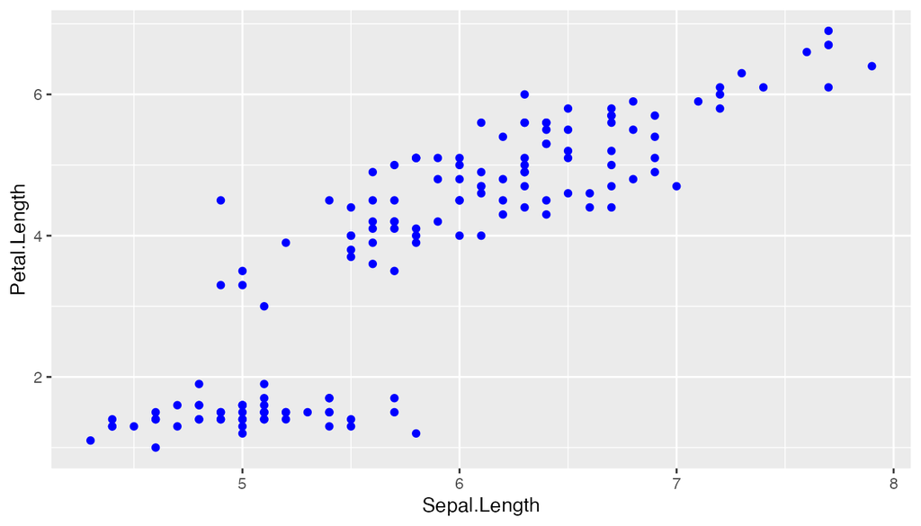

```r
# 全部の点を青にする（aes の外）
ggplot(data = iris, aes(x = Sepal.Length, y = Petal.Length)) +
  geom_point(color = "blue")
```

> **`aes(color = "blue")` と書いてはいけません。** `aes()` の中に書いた `"blue"` は色の指定ではなく，**1つのカテゴリの名前**として扱われます。 そのため青にはならず，全部の点が同じ色（既定の赤っぽい色）になり，凡例に `blue` と表示されます。

もう1つ覚えておくと迷いません。

> **列名には引用符を付けない。色名やタイトルなどの文字列には引用符を付ける。**
> - `aes(x = Petal.Length)` … 列名なので引用符なし
> - `labs(title = "花びらの長さ")` … 文字列なので引用符あり

## 5. ヒストグラム（Histogram）

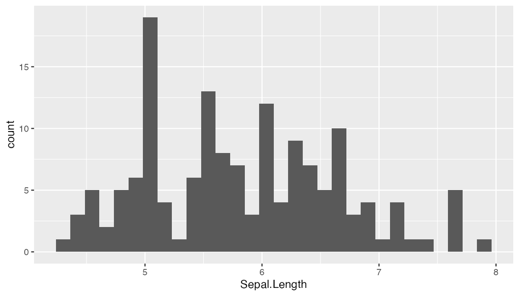

```r
ggplot(data = iris, aes(x = Sepal.Length)) +
  geom_histogram()
```

### 「縦軸はどこで決めたのか」

散布図では `x` と `y` の両方を指定しましたが，ここでは `x` だけです。**縦軸を書いていません。**

> **ヒストグラムは，数値を区間に分けて，その区間に入った観測の個数を自動で数えます。** だから縦軸は**度数（個数）**になります。自分で指定する必要はありません。

実行すると，次のようなメッセージが出ることがあります。

```
`stat_bin()` using `bins = 30`. Pick better value with `binwidth`.
```

**これは失敗ではありません。** 「区間の数を標準の30にしました。自分で決めることもできますよ」という案内です。

### ビンの幅を調整する

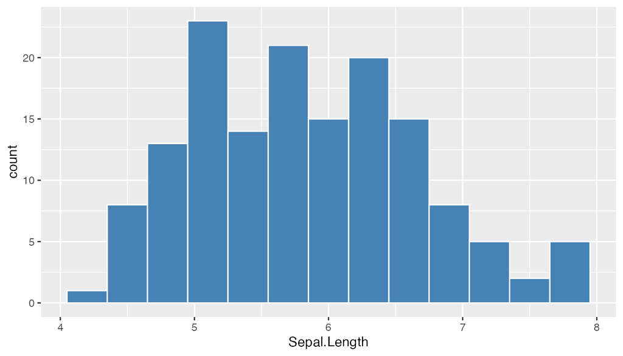

```r
ggplot(data = iris, aes(x = Sepal.Length)) +
  geom_histogram(binwidth = 0.3, fill = "steelblue", color = "white")
```

`binwidth = 0.3` は，**がく片の長さを 0.3cm 刻みの区間に分ける**という指定です。

- **幅を狭くする**（例：0.1）→ 細かい凹凸が見える。ただしガタガタになりやすい
- **幅を広くする**（例：0.5）→ 大まかな形が見える。ただし特徴が消えることがある

> **1つの幅だけ見て判断しないでください。** 幅を変えると印象が変わります。 いくつかの幅を試して，**山の数や偏りがどれくらい変わるか**を見比べてください。 幅の取り方で山が1つに見えたり2つに見えたりします。 **自分の言いたい結論に都合のよい幅だけを選ばない**こと， そして論文やレポートでは**どの幅を使ったかを書く**ことが大事です。

なお `fill = "steelblue"` と `color = "white"` は `aes()` の外にあるので，**全部の棒を同じ色にする固定指定**です。

## 6. 棒グラフ（Bar Plot）

種ごとのデータ件数を棒グラフで表示します。

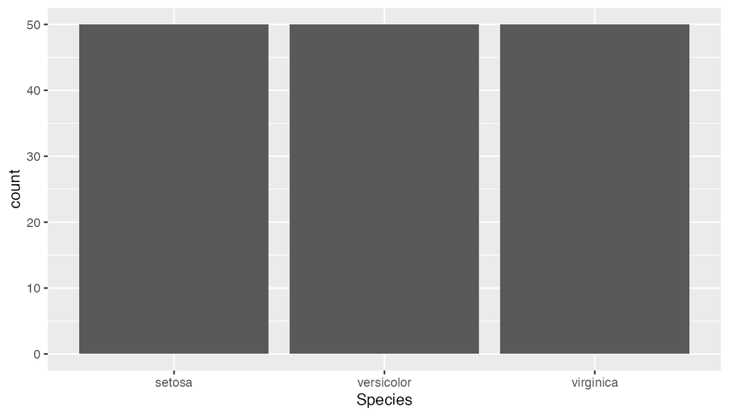

```r
ggplot(data = iris, aes(x = Species)) +
  geom_bar()
```

ここでも `y` を指定していません。**`geom_bar()` は，カテゴリごとの観測数を自動で数えます。**

3本の棒がすべて同じ高さ（50）になりました。これは **`iris` に各種50本ずつ入っているから**です。 「3種が同じ大きさ」とか「自然界に同じ割合でいる」という意味ではありません。

> **すでに計算してある数値を棒の高さにしたいとき**（例：種ごとの平均値）は， `geom_bar()` ではなく **`geom_col()`** を使います。 「数えるのが `geom_bar()`，与えられた値を描くのが `geom_col()`」と覚えてください。

### 色を付ける

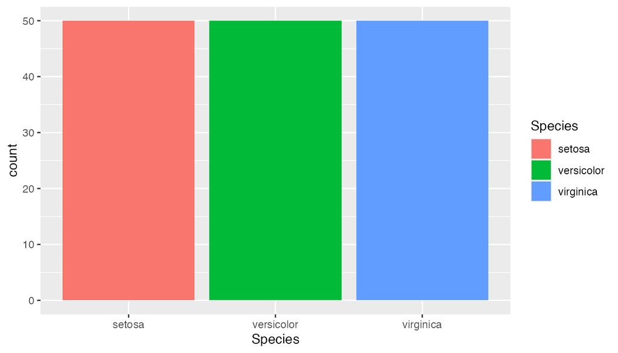

```r
ggplot(data = iris, aes(x = Species, fill = Species)) +
  geom_bar()
```

## 7. 箱ひげ図（Box Plot）

グループ間の分布を比較するのに便利です。

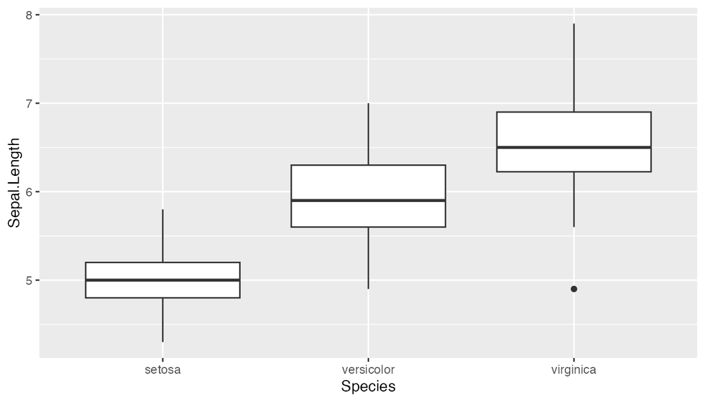

```r
ggplot(data = iris, aes(x = Species, y = Sepal.Length)) +
  geom_boxplot()
```

### 箱ひげ図の読み方

**この図は，次の部品でできています。**

| 部品 | 表しているもの |
| --- | --- |
| **箱の下端** | 第1四分位数（下から25%の位置） |
| **箱の中の線** | **中央値**（真ん中の値） |
| **箱の上端** | 第3四分位数（下から75%の位置） |
| **ひげ** | 箱から離れすぎていない範囲の，最小値・最大値 |
| **ひげの外の点** | ひげの範囲から外れた観測 |

つまり**箱の中に，データの真ん中半分（50%）が入っています。**

> **箱が縦に長い＝真ん中50%のばらつきが大きい。短い＝そろっている。** 箱の高さが表しているのは $IQR$，つまり**中央50%の広がり**です。 分布全体のばらつきは，箱の高さだけでは分かりません（ひげと外側の点も見ること）。 また箱の高さは「件数」ではありません。どの種も50本ずつあります。

ひげについて，もう少し正確に書いておきます。

> ひげは**必ずしも最小値・最大値まで伸びるわけではありません。** 箱の高さ（第3四分位数 − 第1四分位数）を $IQR$ として，
> $$[\,Q_1 - 1.5 \times IQR,\ \ Q_3 + 1.5 \times
> IQR\,]$$
> という範囲を考えます。ひげは，**この範囲に入っている観測のうちの最小値・最大値**まで伸びます。 それより外側の観測は，**点**として個別に描かれます。

> **外側の点を見つけても，「入力ミスだ」「消すべきだ」と決めつけないでください。** 本当に珍しい個体かもしれませんし，重要な発見かもしれません。 まずは「そういう観測がある」と認識するところまでです。

## 8. タイトルと軸ラベルの追加

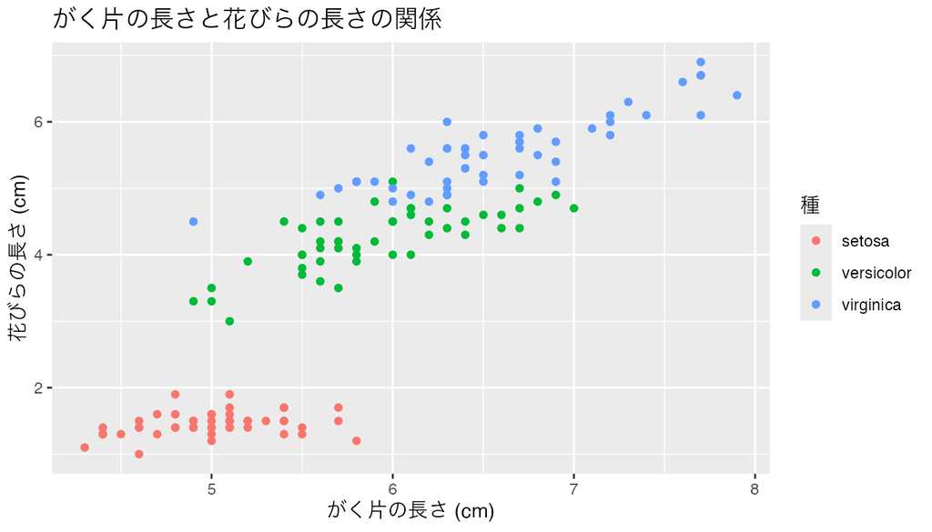

```r
ggplot(data = iris, aes(x = Sepal.Length, y = Petal.Length, color = Species)) +
  geom_point() +
  labs(
    title = "がく片の長さと花びらの長さの関係",
    x = "がく片の長さ (cm)",
    y = "花びらの長さ (cm)",
    color = "種"
  )
```

## 9. aes() のよく使うマッピング

| 引数 | 役割 | 例 |
| --- | --- | --- |
| `x` | x軸の変数 | `x = Sepal.Length` |
| `y` | y軸の変数 | `y = Petal.Length` |
| `color` | 色（線・点） | `color = Species` |
| `fill` | 塗りつぶし色 | `fill = Species` |
| `size` | 点の大きさ | `size = Petal.Width` |
| `shape` | 点の形 | `shape = Species` |

## 演習

### 演習1：散布図

`iris` データを使って，`Petal.Length`（x軸）と `Petal.Width`（y軸）の 散布図を作成し，`Species` で色分けしてください。

```r
ggplot(data = iris, aes(x = ___, y = ___, color = ___)) +
  geom_point()
```

**図ができたら，次の2つに答えてください。回答は `#` を付けてコメントで書きます。**

```r
# 問1：この図の点1つは，何を表していますか
#

# 問2：3つの種のうち，他の2つとはっきり分かれている種はどれですか
#
```

> 点が150個より少なく見えても，データが消えたわけではありません。 **同じ位置に複数の花が重なっている**だけです（150本の花に対し，長さと幅の組合せは102通りしかありません）。

### 演習2：ヒストグラム

`Petal.Width` のヒストグラムを作成し，適切なタイトルと軸ラベルを付けてください。

**`binwidth` は 0.2，色は好きなものを選んで構いません。** 色の正解は1つではありません。

```r
ggplot(data = iris, aes(x = ___)) +
  geom_histogram(binwidth = ___, fill = "___", color = "white") +
  labs(title = "___", x = "___", y = "___")
```

確認してほしいのは次の3点です。

1. `Petal.Width` を使っているか
2. ヒストグラムになっているか
3. タイトルと軸ラベルが，中身と単位に合っているか（縦軸は「度数」や「花の数」）

> **余裕があれば**：`binwidth` を 0.1，0.2，0.4 に変えて，見え方がどう変わるか1文で書いてみてください。

### 演習3：箱ひげ図

種（`Species`）ごとに `Petal.Length` の分布を箱ひげ図で比較してください。 `fill = Species` を追加してカラフルにしてみましょう。

```r
ggplot(data = iris, aes(x = ___, y = ___, fill = ___)) +
  geom_boxplot() +
  labs(title = "___")
```

**図ができたら，次に答えてください。**

```r
# 問：花びらの長さの中央値がいちばん大きい種はどれですか。
#     図のどこを見てそう判断したかも書いてください。
#
```

> setosa の箱は，他の2種より縦に短くなります。 これは**件数が少ないからではありません**（どの種も50本です）。 第1四分位数から第3四分位数までの幅が狭い，つまり**真ん中50%のばらつきが小さい**ということです。

### 模範解答

演習1〜3の解答例を置いてあります。自分で解いたあとに見てください。

**→ 第3回 演習の模範解答（`.R` ファイル）**

> ブラウザで中身が表示されます。保存するときは右クリック →「リンク先を別名で保存」。 RStudioで開いて，**全選択して `Ctrl + Enter`** で実行して確かめてください。

## 本日のまとめ

- `ggplot2` はレイヤーを重ねてグラフを作る
- 基本の構造は **`ggplot(data = ..., aes(...)) + geom_xxx()`**
- **`aes()` の中は「データを見た目に対応づける」，外は「見た目を固定する」**
- ヒストグラムと棒グラフの**縦軸は自動で数えた度数**。自分で指定しない
- 箱ひげ図の**箱はデータの真ん中半分，中の線は中央値**
- 散布図（`geom_point()`），ヒストグラム（`geom_histogram()`），棒グラフ（`geom_bar()`），箱ひげ図（`geom_boxplot()`）を作れるようになった
- `labs()` でタイトル・軸ラベルを追加できる

## 宿題・予習

- **`library(tidyverse)` と演習1〜3の作図コードを，1つの `.R` ファイルにまとめて保存する**
  - 保存するのは**画像ではなく，グラフを作るコード**です
  - 保存のしかた（`Ctrl + S` / `Cmd + S`）と**どこに置くか**は， 第2回の「まずスクリプトを1つ作る」を見てください
  - 完了の条件は，**保存した `.R` ファイルを開き直し，上から順にコードを実行して3つの図が表示できること**
  - RStudio では，**全選択（`Ctrl + A`）してから `Ctrl + Enter`**（Mac は `Cmd + A` → `Cmd + Enter`） でまとめて実行できます。1行ずつ実行する必要はありません
  - `source("ファイル名.R")` でまとめて実行すると**図が表示されません**。 まとめて実行したい人は `p1 <- ggplot(...) + ...` と変数に入れ，`print(p1)` を書いてください
  - 詰まったときは模範解答を見て構いません
- 次回は **グラフのカスタマイズと保存**（画像ファイルとして書き出す方法）を学びます
- 教科書の可視化に関する章を読んでおくと理解が深まります